# Text preparation, processing, and generation of DFM

Constantine Boussalis

1 February 2022

### Overview of basic text preparation steps using **quanteda**

In practical applications we will want to bring in a collected corpus into quanteda for analysis.

Assume that you have scraped English language articles from two North Korean news outlets for the year 2015. Your corpus consists of articles from: the Korean Central News Agency (KCNA) and the *Rodong Sinmun* (ROSI), which is the official newspaper of the Central Committee of the Workers’ Party of Korea. You have written the text and document-level variables to disk as a comma-separated values (.csv) file.

Below is code which will take you through the basic text preparation and processing workflow.

### Bringing in the text

Below is code which will allow you to construct a quanteda corpus using external data using the **readtext** function. We will be using this text data for the remainder of the tutorial.

Our first task is to bring in the text and metadata (also called `docvars` in `quanteda` terminology) into a format that will serve as a reference corpus object will serve all downstream applications. Below we bring in the data usine `readtext`, create a corpus object using the `corpus` function, and then display the summary stats for the first 3 documents in the corpus object.

```r
library(quanteda)
library(readtext) # for importing external corpus data

# Read in csv file with readtext. Note this address will be different for your system.
kcna_csv <- readtext("./data/kcna_example2015.csv",
                     text_field = "newsText") # the column with the header "newsText" in the csv contains the article text.

# Create a quanteda corpus using the imported data
corpus_kcna <- corpus(kcna_csv)

# Summarize the KCNA corpus. Only show the first 3 documents.
summary(corpus_kcna, 3)
```

```
## Corpus consisting of 11863 documents, showing 3 documents:
##
##                    Text Types Tokens Sentences   newsDate        newsID
##  kcna_example2015.csv.1    71    100         3 01/01/2015 2015-01-01_01
##  kcna_example2015.csv.2  1354   4820       128 01/01/2015 2015-01-01_02
##  kcna_example2015.csv.3    76    122         5 01/01/2015 2015-01-01_03
##                                                                                              newsLink
##  https://kcnawatch.co/newstream/1451904012-614241434/south-korean-students-protest-dissolution-of-upp
##                     https://kcnawatch.co/newstream/1451904054-247208692/kim-jong-uns-new-year-address
##              https://kcnawatch.co/newstream/1451904138-712872651/dprk-citizens-enjoying-new-years-day
##                                         newsTitle source
##  South Korean Students Protest Dissolution of UPP   KCNA
##                    Kim Jong Un's New Year Address   KCNA
##             DPRK Citizens Enjoying New Year's Day   KCNA
```

The corpus consists of 11863 documents and important *docvars*: newsDate, newsID, newsLink, newsTitle, source

We can save the summary information into a dataframe and use the information to plot some descriptive statistics that might be informative. For instance, the number of daily tokens:

```r
library(ggplot2)
library(dplyr)
library(lubridate)
token_stats <- summary(corpus_kcna, n = nrow(docvars(corpus_kcna))) # get summary information on entire corpus
names(token_stats) # print variable names in corpus summary object
```

```
## [1] "Text"      "Types"     "Tokens"    "Sentences" "newsDate"  "newsID"
## [7] "newsLink"  "newsTitle" "source"
```

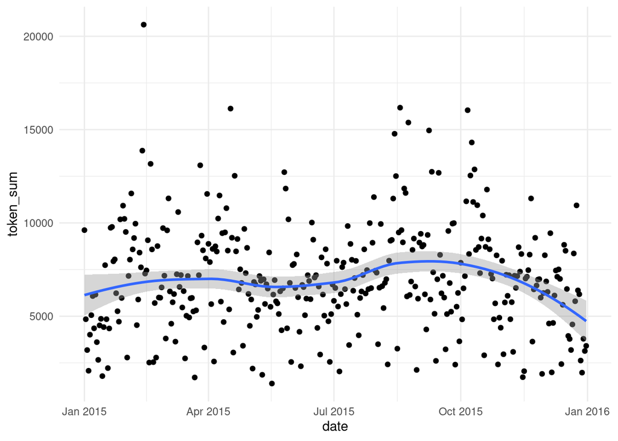

```r
daily_tokens <- token_stats %>%
  group_by(newsDate) %>%
  summarize(token_sum = sum(Tokens)) # Sum of tokens by date

daily_tokens$date <- dmy(daily_tokens$newsDate) # create date variable from string variable; dmy() because format is day/month/year
ggplot(data=daily_tokens, aes(x=date, y=token_sum, group = 1)) + geom_point() + geom_smooth() + theme_minimal()
```

### Keywords in context (KWIC)

Before we process our text and create a document-feature matrix, we can inspect our corpus for keywords of interest using the Keywords in context (KWIC) functionality in **quanteda**. The `kwic()` function takes the `pattern` argument and returns a list of the keyword in its context.

Let’s see a glimpse of how the NK news discussed the term “nuclear” in 2015.

```r
nuclear_kwic <- kwic(corpus_kcna,
                     pattern = "nuclear",
                     window = 5,
                     case_insensitive = TRUE)
head(nuclear_kwic)
```

```
## Keyword-in-context with 6 matches.
##  [kcna_example2015.csv.2, 3744]              peninsula and the danger of |
##  [kcna_example2015.csv.2, 3785]                     partner. To cling to |
##  [kcna_example2015.csv.2, 4488]    attempt to destroy our self-defensive |
##  [kcna_example2015.csv.2, 4539] self-reliant defence capability with the |
##  [kcna_example2015.csv.11, 157]               into a military power with |
##  [kcna_example2015.csv.28, 137] self-reliant defence capability with the |
##
##  nuclear | war facing our nation.
##  nuclear | war drills against the fellow
##  nuclear | deterrent and stifle our Republic
##  nuclear | deterrent as its backbone and
##  nuclear | deterrent by providing his Songun
##  nuclear | deterrent as its backbone and
```

Note that you can use the `valutype` argument to search for patterns using “glob”-style wildcard expressions, “regex” for regular expressions, or “fixed” for exact matches. For instances, take the example pattern of “aggress*” using a glob-style pattern:

```r
tmp_kwic <- kwic(corpus_kcna,
                 pattern = "aggress*",
                 window = 5,
                 case_insensitive = TRUE,
                 valuetype = "glob")
head(tmp_kwic)
```

```
## Keyword-in-context with 6 matches.
##  [kcna_example2015.csv.2, 3795] fellow countrymen in collusion with |
##  [kcna_example2015.csv.2, 3912]           DPRK and reckless acts of |
##  [kcna_example2015.csv.20, 242]           DPRK and reckless acts of |
##  [kcna_example2015.csv.46, 251]         DPRK and reckless moves for |
##  [kcna_example2015.csv.46, 306]       the war policy of imperialist |
##   [kcna_example2015.csv.59, 61]         denying its past history of |
##
##  aggressive | outside forces is an extremely
##  aggression | and boldly make a policy
##  aggression | and boldly make a policy
##  aggression | . The DPRK always remains
##  aggression | forces and their moves of
##  aggression | , turning blind eyes to
```

So, we can use KWIC to get a quick feel for important keywords in our corpus.

### Text Processing

Once we have pulled in our text and created a corpus, the next step is to process the text prior to generating a document-feature matrix. In the code below, we will process the text step by step using the `tokens` function to create a `tokens` object, while observing the changes made at each stage of the pipeline.

The demonstration will proceed as follows:

1. Tokenize the documents
2. Lowercasing
3. Removal of numbers, punctuation, hyphens, symbols, separators, and URLs.
4. Stopword removal
5. Stemming

Before we begin, here is the full text from an example article that we will be observing through the text processing sequence.

```r
corpus_kcna[[6]] # print original text from example article
```

```
## [1] "  Supreme leader Kim Jong Un received messages from the organizations of the General Association of Korean Residents in Japan (Chongryon) and its affiliated organizations on the New Year, Juche 104 (2015). They were the Standing Council of the Korean Federation of Workers in Commerce in Japa…
```

Let’s tokenize our documents and take a look at our example article after tokenization. Note that we will set `include_docvars = TRUE` so that the `tokens` object retains the `docvars` dataframe (which contains document-level variables). This will be useful downstream when we wish to conduct our analysis.

```r
toks <- tokens(corpus_kcna,
               include_docvars = TRUE)

toks[[6]][1:50] # show first 50 tokens from example article
```

```
##  [1] "Supreme"       "leader"        "Kim"           "Jong"
##  [5] "Un"            "received"      "messages"      "from"
##  [9] "the"           "organizations" "of"            "the"
## [13] "General"       "Association"   "of"            "Korean"
## [17] "Residents"     "in"            "Japan"         "("
## [21] "Chongryon"     ")"             "and"           "its"
## [25] "affiliated"    "organizations" "on"            "the"
## [29] "New"           "Year"          ","             "Juche"
## [33] "104"           "("             "2015"          ")"
## [37] "."             "They"          "were"          "the"
## [41] "Standing"      "Council"       "of"            "the"
## [45] "Korean"        "Federation"    "of"            "Workers"
## [49] "in"            "Commerce"
```

We can see a number of useful and not so useful tokens in this example. As a first step of reducing the dimensionality of the corpus, let’s lowercase all the tokens.

```r
toks <- tokens_tolower(toks)
toks[[6]][1:50]
```

```
##  [1] "supreme"       "leader"        "kim"           "jong"
##  [5] "un"            "received"      "messages"      "from"
##  [9] "the"           "organizations" "of"            "the"
## [13] "general"       "association"   "of"            "korean"
## [17] "residents"     "in"            "japan"         "("
## [21] "chongryon"     ")"             "and"           "its"
## [25] "affiliated"    "organizations" "on"            "the"
## [29] "new"           "year"          ","             "juche"
## [33] "104"           "("             "2015"          ")"
## [37] "."             "they"          "were"          "the"
## [41] "standing"      "council"       "of"            "the"
## [45] "korean"        "federation"    "of"            "workers"
## [49] "in"            "commerce"
```

Now we don’t need to be worried about unnecessary duplicate types, where one happens to be capitalized due to grammatical syntax.

Notice how there numbers, punctuation and symbols still in the sample document (there could also be hyphens, separators, and URLs in the corpus). Let’s remove them all.

```r
toks <- tokens(toks,
               remove_numbers = TRUE,
               remove_punct = TRUE,
               remove_symbols = TRUE,
               remove_hyphens = TRUE,
               remove_separators = TRUE,
               remove_url = TRUE)
toks[[6]][1:50]
```

```
##  [1] "supreme"       "leader"        "kim"           "jong"
##  [5] "un"            "received"      "messages"      "from"
##  [9] "the"           "organizations" "of"            "the"
## [13] "general"       "association"   "of"            "korean"
## [17] "residents"     "in"            "japan"         "chongryon"
## [21] "and"           "its"           "affiliated"    "organizations"
## [25] "on"            "the"           "new"           "year"
## [29] "juche"         "they"          "were"          "the"
## [33] "standing"      "council"       "of"            "the"
## [37] "korean"        "federation"    "of"            "workers"
## [41] "in"            "commerce"      "in"            "japan"
## [45] "central"       "standing"      "committee"     "of"
## [49] "the"           "korean"
```

That cleaned up a lot of unwanted tokens. Now, let’s deal with stopwords—types that are theoretically uninformative but are very frequent (e.g., prepositions, articles, etc.).

To demonstrate how frequent these stop words are, let’s look at the most frequent tokens overall in our tokens object. (note that I am skipping ahead here by creating a document-feature matrix; this is only for demonstration at the moment.)

```r
tmp_dfm <- dfm(toks)
topfeatures(tmp_dfm)
```

```
##    the     of    and     to     in      a    for     on    kim     by
## 251897 135378  94480  49428  47131  37363  26910  26395  22479  16422
```

By far, the most frequent tokens are not very useful stopwords We can use a pre-built list of such stopwords to remove them from the `tokens` object we are working with. First, let’s load this list and take a look at it.

```r
stop_list <- stopwords("english") # load English stopwords from quanteda
print(stop_list[1:50]) # print first 50 stopword tokens from list
```

```
##  [1] "i"          "me"         "my"         "myself"     "we"
##  [6] "our"        "ours"       "ourselves"  "you"        "your"
## [11] "yours"      "yourself"   "yourselves" "he"         "him"
## [16] "his"        "himself"    "she"        "her"        "hers"
## [21] "herself"    "it"         "its"        "itself"     "they"
## [26] "them"       "their"      "theirs"     "themselves" "what"
## [31] "which"      "who"        "whom"       "this"       "that"
## [36] "these"      "those"      "am"         "is"         "are"
## [41] "was"        "were"       "be"         "been"       "being"
## [46] "have"       "has"        "had"        "having"     "do"
```

This is a character vector of 175 lowercased stop words that `quanteda` has provided us. In some cases, we might want to append corpus-specific stopwords to this vector. We could simply do this by using the `append` command. Also, note that sometimes you may want to restrict the stop word list (e.g., you are theoretically interested in gender-related stopwords).

Let’s remove the stopwords from our `tokens` object using the vanilla stopword list.

```r
toks <- tokens_remove(toks, stop_list)
toks[[6]][1:50]
```

```
##  [1] "supreme"       "leader"        "kim"           "jong"
##  [5] "un"            "received"      "messages"      "organizations"
##  [9] "general"       "association"   "korean"        "residents"
## [13] "japan"         "chongryon"     "affiliated"    "organizations"
## [17] "new"           "year"          "juche"         "standing"
## [21] "council"       "korean"        "federation"    "workers"
## [25] "commerce"      "japan"         "central"       "standing"
## [29] "committee"     "korean"        "youth"         "league"
## [33] "japan"         "central"       "standing"      "committee"
## [37] "korean"        "democratic"    "women's"       "union"
## [41] "japan"         "central"       "standing"      "management"
## [45] "board"         "korean"        "youth"         "commercial"
## [49] "association"   "japan"
```

We have done a pretty good job in cleaning the text thus far. If we wished, we could further normalize the tokens by *stemming* the tokens in our corpus. `quanteda` provides a very easy stemming function which can be apply straight to our tokens object.

```r
toks <- tokens_wordstem(toks)
toks[[6]][1:50]
```

```
##  [1] "suprem"    "leader"    "kim"       "jong"      "un"        "receiv"
##  [7] "messag"    "organ"     "general"   "associ"    "korean"    "resid"
## [13] "japan"     "chongryon" "affili"    "organ"     "new"       "year"
## [19] "juch"      "stand"     "council"   "korean"    "feder"     "worker"
## [25] "commerc"   "japan"     "central"   "stand"     "committe"  "korean"
## [31] "youth"     "leagu"     "japan"     "central"   "stand"     "committe"
## [37] "korean"    "democrat"  "women"     "union"     "japan"     "central"
## [43] "stand"     "manag"     "board"     "korean"    "youth"     "commerci"
## [49] "associ"    "japan"
```

By stemming, we are able to collapse multiple forms of the same term onto a single type by reducing the inflections of words and collapsing onto the base form of the word. We can see, however, that some tokens might become difficult to interpret and that different words can merge together erroneously because they happen to have a common base form. We should always be cognizant of these trade-offs when deciding to stem.

#### Collocations and compounding multi-word expressions

There are usually terms in our corpus that are multi-word expressions (collocations) and should be treated as individual tokens in our analysis downstream. Sometimes, we have theoretical priors on what these terms are. For instance, in the current corpus, we can be fairly confident that the term “Kim Jong Un” will show up. On the other hand, there may be terms that are frequent but that we cannot anticipate. In this case, it would be useful to employ an unsupervised collocation detection method, and then compound the constituent words in the collocation based on the results of this analysis.

We can compound the tokens in our corpus by creating and manipulating a `tokens` object from our corpus.

First, let’s do some exploration. How are some well-known multi-word expressions used in the corpus?

1. Create a `tokens` object from our quanteda corpus object
2. Ensure that the tokens object does not have stopwords, that the tokens are lowercased, and we will also remove punctuation and separators with regular expressions.
3. Then we will perform some KWIC commands to inspect usage of known collocations. Note that we set the `padding` argument to true in the `tokens_remove` function so as to make sure that there is a whitespace in place of a removed stopword. This will ensure proper positional matching when detecting the collocations.

```r
toks_kcna <- tokens(corpus_kcna,
                    include_docvars = TRUE) %>%
  tokens_tolower() %>%
  tokens_remove(stopwords('english'), padding = TRUE) %>%
  tokens_remove('[\\p{P}\\p{S}]', valuetype = 'regex', padding = TRUE)

leader_col <- kwic(toks_kcna, pattern = phrase(c('kim jong un', 'kim jong il', 'kim il sung', 'supreme leader')))
head(leader_col, 10)
```

```
## Keyword-in-context with 10 matches.
##      [kcna_example2015.csv.2, 1:3]                                | kim jong un
##  [kcna_example2015.csv.2, 120:122]   new year greetings president | kim il sung
##  [kcna_example2015.csv.2, 125:127]            kim il sung general | kim jong il
##      [kcna_example2015.csv.4, 1:3]                                | kim jong un
##    [kcna_example2015.csv.4, 48:50] paid highest tribute president | kim il sung
##    [kcna_example2015.csv.4, 53:55]             kim il sung leader | kim jong il
##  [kcna_example2015.csv.4, 342:344]                lifelong desire | kim il sung
##  [kcna_example2015.csv.4, 346:348]                    kim il sung | kim jong il
##    [kcna_example2015.csv.5, 77:79]              statues president | kim il sung
##    [kcna_example2015.csv.5, 82:84]             kim il sung leader | kim jong il
##
##  | first secretary
##  | general kim jong il
##  | eternal leaders
##  | first secretary
##  | leader kim jong il
##  | sent new year
##  | kim jong il
##  | greatest cherished desire
##  | leader kim jong il
##  | floral basket
```

It’s clear that these “leader name collocations” are important. What’s more, there are 17796 of them—so it is important that we convert these sequences of tokens into a single compound token. This can be done using `tokens_compound`. We will connect these tokens using an underscore (_) as the concatenator.

```r
leader_phrases <- phrase(c('kim jong un',
                           'kim jong il',
                           'kim il sung',
                           'supreme leader')) # create phrase object of terms of interest (whitespaces are parsed into character elements)

toks_kcna_col <- tokens_compound(toks_kcna,
                                 pattern = leader_phrases,
                                 concatenator = "_",
                                 case_insensitive = TRUE)
```

We can compare the tokens of an example document before and after we converted these collocations into a single compound token.

```r
# Example document before converting "leader" collocations
toks_kcna[[6]][1:30] # show first 30 tokens
```

```
##  [1] "supreme"       "leader"        "kim"           "jong"
##  [5] "un"            "received"      "messages"      ""
##  [9] ""              "organizations" ""              ""
## [13] "general"       "association"   ""              "korean"
## [17] "residents"     ""              "japan"         ""
## [21] "chongryon"     ""              ""              ""
## [25] "affiliated"    "organizations" ""              ""
## [29] "new"           "year"
```

Notice how “supreme leader” and “kim jong un” are segmented into their constituent tokens. Also, see how there are empty tokens that used to be stopwords and how some other tokens could be potential collocations (e.g., “general association”)

Now let’s compare these tokens to those from the converted tokens object.

```r
# Example document after converting "leader" collocations
toks_kcna_col[[6]][1:30] # show first 30 tokens
```

```
##  [1] "supreme_leader" "kim_jong_un"    "received"       "messages"
##  [5] ""               ""               "organizations"  ""
##  [9] ""               "general"        "association"    ""
## [13] "korean"         "residents"      ""               "japan"
## [17] ""               "chongryon"      ""               ""
## [21] ""               "affiliated"     "organizations"  ""
## [25] ""               "new"            "year"           ""
## [29] "juche"          "104"
```

Clearly there are a great number of collocations still embedded within the tokens object. Let’s use an unsupervised approach to discover the most common ones. For this, we will use `textstat_collocations` on the existing converted tokens object.

```r
library(quanteda.textstats)
unsup_col <- textstat_collocations(toks_kcna_col,
                                     method = "lambda",
                                     size = 2,
                                     min_count = 10,
                                     smoothing = 0.5)
```

The routine has returned 7133 collocations that occur at least 10 times in the corpus. We can inspect the top 25 detected collocations in terms of frequency:

```r
unsup_col <- unsup_col[order(-unsup_col$count),] # sort detected collocations by count (descending)
head(unsup_col, 25)
```

```
##                collocation count count_nested length    lambda         z
## 1             south korean  5009            0      2  5.238622 244.55216
## 9                news team  3569            0      2 10.415928 161.30952
## 2              south korea  3484            0      2  5.194204 216.35386
## 3    president kim_il_sung  3045            0      2  6.525409 212.04275
## 6            korean people  2995            0      2  4.322886 185.31052
## 5                 kim jong  2727            0      2  7.684095 189.43967
## 4       leader kim_jong_il  2378            0      2  6.796800 192.96458
## 10            human rights  2227            0      2 10.348484 141.51426
## 8        central committee  1745            0      2  6.915804 163.10012
## 24        korean peninsula  1698            0      2  6.415913 122.00849
## 7               juche idea  1672            0      2  7.356674 172.28437
## 12              took place  1615            0      2  9.891237 137.14670
## 11      korean authorities  1530            0      2  5.203415 137.81257
## 13     marshal kim_jong_un  1339            0      2  7.678180 136.57848
## 20           korean puppet  1242            0      2  4.891854 125.50504
## 108      service personnel  1080            0      2 11.218420  77.83273
## 76       birth anniversary  1048            0      2  8.513313  91.84636
## 17  national reunification   988            0      2  5.066931 129.11893
## 15        70th anniversary   957            0      2  6.393761 133.61558
## 14                 june 15   897            0      2  8.295240 134.21159
## 18    founding anniversary   892            0      2  6.396600 129.10844
## 33        national defence   885            0      2  6.960410 111.96782
## 140        communist party   876            0      2  7.933508  72.21232
## 19       joint declaration   822            0      2  7.510051 125.70537
## 69           korean nation   820            0      2  3.830969  94.80158
```

Some of these collocations do indeed look informative, while others might not. What about the 25 (relatively) infrequent detected collocations?

```r
tail(unsup_col, 25)
```

```
##               collocation count count_nested length      lambda           z
## 7032        new socialist    10            0      2  1.26048556  4.06879915
## 7033        also chairman    10            0      2  1.23343581  3.98097617
## 7036         people built    10            0      2  1.19877653  3.85591231
## 7048         dprk shining    10            0      2  1.09145530  3.50385569
## 7050  revolutionary youth    10            0      2  1.08153054  3.49096255
## 7052            city said    10            0      2  1.07183675  3.45721713
## 7067   founding committee    10            0      2  0.88175727  2.84646366
## 7069       national issue    10            0      2  0.87221023  2.81553260
## 7084      dprk prosperity    10            0      2  0.68156031  2.19456792
## 7088           dprk photo    10            0      2  0.64438062  2.07530280
## 7091            dprk even    10            0      2  0.57598874  1.85574205
## 7092       korean council    10            0      2  0.57157133  1.84088890
## 7103  relations committee    10            0      2  0.18997391  0.61415483
## 7107          dprk public    10            0      2  0.05421579  0.17505609
## 7108         dprk marshal    10            0      2 -0.02703684 -0.08732038
## 7109       dprk including    10            0      2 -0.03155091 -0.10190076
## 7110    revolutionary war    10            0      2 -0.04158416 -0.13447656
## 7111          people held    10            0      2 -0.09408167 -0.30412756
## 7114      dprk friendship    10            0      2 -0.11366500 -0.36719152
## 7115          dprk policy    10            0      2 -0.11986979 -0.38724239
## 7121    south authorities    10            0      2 -0.20258938 -0.65497998
## 7125           dprk peace    10            0      2 -0.46705979 -1.51003844
## 7126            dprk held    10            0      2 -0.47106131 -1.52298720
## 7129 revolutionary people    10            0      2 -0.63292265 -2.04759691
## 7130         great korean    10            0      2 -1.11654456 -3.61298761
```

Indeed, many of these collocations don’t look very helpful. So, we can pick and choose from the the most frequent detected collocations and create a phrase object as we did above. Or we can replace token sequences with all collocations from this list that pass some (arbitrary) threshold; say, `z > 3`. Let’s do the latter:

```r
toks_kcna_col <- tokens_compound(toks_kcna_col,
                                 pattern = unsup_col[unsup_col$z > 3])

toks_kcna_col <- tokens_remove(tokens(toks_kcna_col), "") # let's also remove the whitespace placeholders
```

We can inspect the changes made to one of the previous texts that we looked at.

```r
# Example document after converting collocations using an unsupervised method
toks_kcna_col[[6]][1:50] # show first 50 tokens
```

```
##  [1] "supreme_leader_kim_jong_un_received"
##  [2] "messages"
##  [3] "organizations"
##  [4] "general_association"
##  [5] "korean_residents"
##  [6] "japan"
##  [7] "chongryon"
##  [8] "affiliated_organizations"
##  [9] "new_year"
## [10] "juche_104"
## [11] "2015"
## [12] "standing_council"
## [13] "korean_federation"
## [14] "workers"
## [15] "commerce"
```

[output cut: 35 more lines]

Now we can see that many token sequences have been replaced with meaningful collocations that were detected by our routine above. The point to remember here is that you will want to be sensitive to how aggressive your approach will be. For instance, the first token in this document “supreme_leader_kim_jong_un_received” might not be helpful downstream. You can always go back and adjust the threshold for conversion.

### Construction of document-feature matrix and feature selection

Having processed the text, we will now generate of “bag of words” representation of the corpus. That is, we will construct a document-feature matrix. Then, we will think about how we can further reduce the dimensionality of the matrix without losing crucial information.

To create a document-feature matrix (DFM), we can use the `dfm` function in quanteda. This function accepts character vectors, `corpus` objects, `tokens` objects, and other `dfm` objects. Take a look at the documentation, as there are really fast ways to convert a corpus into a DFM. For instance, we could construct a DFM while performing all the cleaning steps we did above as follows:

```
dfm_kcna_stem <- corpus_kcna %>%
  quanteda::tokens(remove_numbers = TRUE,
                   remove_punct = TRUE,
                   remove_symbols = TRUE,
                   remove_hyphens = TRUE,
                   remove_separators = TRUE,
                   remove_url = TRUE,
                   include_docvars = TRUE) %>%
  tokens_wordstem() %>%
  dfm() # clean and stem

dfm_kcna_stem_nostops <- dfm_select(dfm_kcna_stem, pattern = stopwords("en"), selection = "remove") # remove stop words on cleaned dfm
```

For our purposes, I will bring in the “toks_kcna_col” `tokens` object that contains the collocations we replaced before and which does not have stemmed tokens. Note that we could simply pass the argument `stem = TRUE` at this point to stem the tokens if we so wished.

```r
dfm_kcna <- dfm(toks_kcna_col) # create a DFM
dfm_kcna
```

```
## Document-feature matrix of: 11,863 documents, 30,437 features (99.78% sparse) and 5 docvars.
##                         features
## docs                     students nine universities including sungkyunkwan
##   kcna_example2015.csv.1        1    1            1         1            1
##   kcna_example2015.csv.2        1    0            0         6            0
##   kcna_example2015.csv.3        0    0            0         0            0
##   kcna_example2015.csv.4        0    0            0         0            0
##   kcna_example2015.csv.5        0    0            0         0            0
##   kcna_example2015.csv.6        0    0            0         0            0
##                         features
## docs                     university hanyang kangwon national_university
##   kcna_example2015.csv.1          2       1       1                   1
##   kcna_example2015.csv.2          0       0       0                   0
##   kcna_example2015.csv.3          0       0       0                   0
##   kcna_example2015.csv.4          0       0       0                   0
##   kcna_example2015.csv.5          0       0       0                   0
##   kcna_example2015.csv.6          0       0       0                   0
##                         features
## docs                     south_korea_made_public
##   kcna_example2015.csv.1                       1
##   kcna_example2015.csv.2                       0
##   kcna_example2015.csv.3                       0
##   kcna_example2015.csv.4                       0
##   kcna_example2015.csv.5                       0
##   kcna_example2015.csv.6                       0
## [ reached max_ndoc ... 11,857 more documents, reached max_nfeat ... 30,427 more features ]
```

Let’s take a look at some properties of the DFM. For instance, what are the most frequent features? The `topfeatures` function gives us some sense:

```r
topfeatures(dfm_kcna)
```

```
##      dprk     party    people     korea      said   country   workers     japan
##     12640      5828      5802      5152      3938      3899      3750      3239
## president       wpk
##      3202      3079
```

We can also visualize, say, the top 100 features using a *wordcloud*:

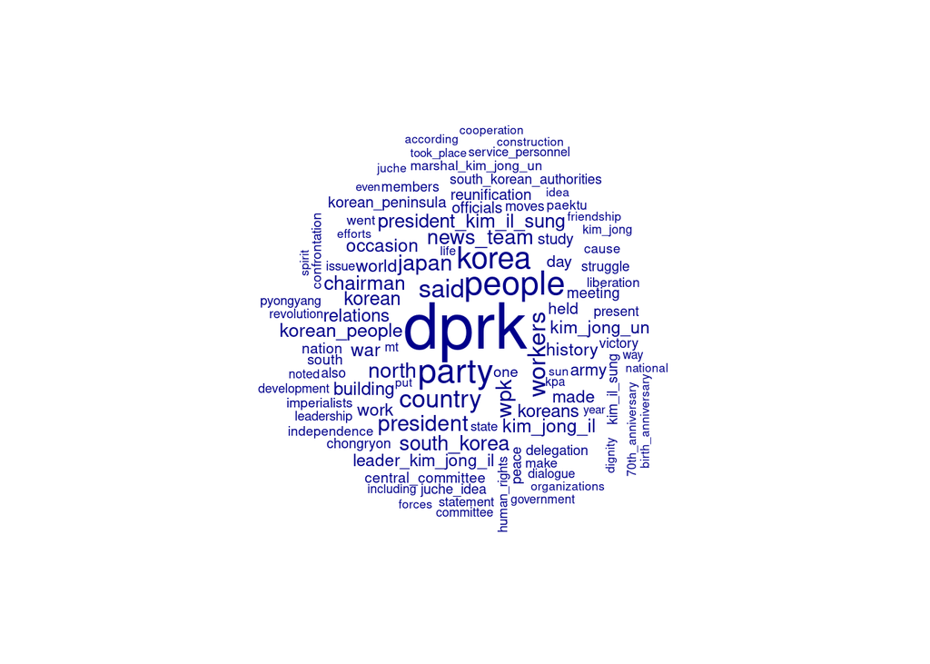

```r
require(quanteda.textplots)
set.seed(1234)
textplot_wordcloud(dfm_kcna, max_words = 100)
```

Perhaps more informative would be to plot the frequencies of the top, say, 30 features:

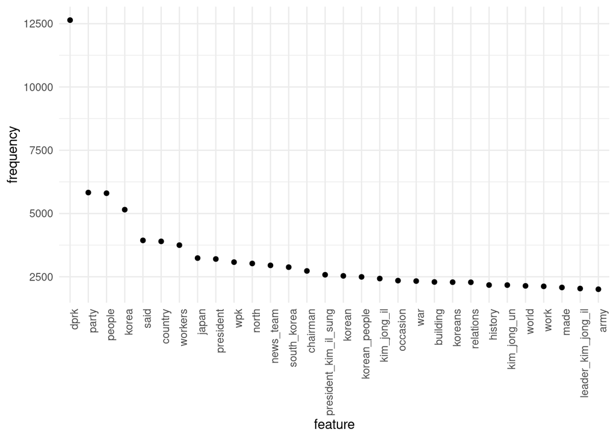

```r
kcna_freq <- textstat_frequency(dfm_kcna, n = 30)
# sort features by frequency in descending order
kcna_freq$feature <- with(kcna_freq, reorder(feature, -frequency))
# plot feature frequencies
ggplot(kcna_freq, aes(x = feature, y = frequency)) +
       geom_point() + theme_minimal() + theme(axis.text.x = element_text(angle = 90, hjust = 1))
```

#### Further dimensionality reducion of the DFM

A DFM of a large corpus such as ours is likely to have a significant number of features that appear sporadically. We might want to remove very rare features from our DFM so that the dimensionality of the matrix can be reduced further. By doing so, we can reduce computational costs during the analysis stage. This might also help discard generally irrelevant features.

To demonstrate this, let’s only keep features that appear at least, say, 10 times in the corpus. We can accomplish this with `trim`.

```r
dfm_kcna_trim <- dfm_trim(dfm_kcna,
                          min_termfreq = 10,
                          verbose = TRUE)
```

```
## Removing features occurring:
```

```
##   - fewer than 10 times: 17,104
```

```
##   Total features removed: 17,104 (56.2%).
```

Notice how the number of features has dropped significantly relative to the original DFM:

```r
dfm_kcna
```

```
## Document-feature matrix of: 11,863 documents, 30,437 features (99.78% sparse) and 5 docvars.
##                         features
## docs                     students nine universities including sungkyunkwan
##   kcna_example2015.csv.1        1    1            1         1            1
##   kcna_example2015.csv.2        1    0            0         6            0
##   kcna_example2015.csv.3        0    0            0         0            0
##   kcna_example2015.csv.4        0    0            0         0            0
##   kcna_example2015.csv.5        0    0            0         0            0
##   kcna_example2015.csv.6        0    0            0         0            0
##                         features
## docs                     university hanyang kangwon national_university
##   kcna_example2015.csv.1          2       1       1                   1
##   kcna_example2015.csv.2          0       0       0                   0
##   kcna_example2015.csv.3          0       0       0                   0
##   kcna_example2015.csv.4          0       0       0                   0
##   kcna_example2015.csv.5          0       0       0                   0
##   kcna_example2015.csv.6          0       0       0                   0
##                         features
## docs                     south_korea_made_public
##   kcna_example2015.csv.1                       1
##   kcna_example2015.csv.2                       0
##   kcna_example2015.csv.3                       0
##   kcna_example2015.csv.4                       0
##   kcna_example2015.csv.5                       0
##   kcna_example2015.csv.6                       0
## [ reached max_ndoc ... 11,857 more documents, reached max_nfeat ... 30,427 more features ]
```

```r
dfm_kcna_trim
```

```
## Document-feature matrix of: 11,863 documents, 13,333 features (99.53% sparse) and 5 docvars.
##                         features
## docs                     students nine universities including university
##   kcna_example2015.csv.1        1    1            1         1          2
##   kcna_example2015.csv.2        1    0            0         6          0
##   kcna_example2015.csv.3        0    0            0         0          0
##   kcna_example2015.csv.4        0    0            0         0          0
##   kcna_example2015.csv.5        0    0            0         0          0
##   kcna_example2015.csv.6        0    0            0         0          0
##                         features
## docs                     kangwon national_university south_korea_made_public
##   kcna_example2015.csv.1       1                   1                       1
##   kcna_example2015.csv.2       0                   0                       0
##   kcna_example2015.csv.3       0                   0                       0
##   kcna_example2015.csv.4       0                   0                       0
##   kcna_example2015.csv.5       0                   0                       0
##   kcna_example2015.csv.6       0                   0                       0
##                         features
## docs                     joint_statement dec
##   kcna_example2015.csv.1               1   1
##   kcna_example2015.csv.2               0   0
##   kcna_example2015.csv.3               0   0
##   kcna_example2015.csv.4               0   0
##   kcna_example2015.csv.5               0   0
##   kcna_example2015.csv.6               0   0
## [ reached max_ndoc ... 11,857 more documents, reached max_nfeat ... 13,323 more features ]
```

By reducing the number of features by either using a threshold of minimum term frequency or minimum document frequency (number of documents the term appears in), we can help boost computational efficiency. Of course, trimming comes at the expense of removing features that could be informative. It is important to be sensitive to this trade-off.

### Save DFM to disk

We can save the untrimmed dfm to disk for future analysis.

```r
getwd() # get working directory
```

```
## [1] "/home/constantine/Dropbox/TRINITY/POP77022 - QTA/lectures/2_text_preparation_statistics"
```

```r
saveRDS(dfm_kcna, file = "dfm_kcna.Rds")
```